# Homework 1

Miles Tweed

# Problem 1

## 1.1

The plot of crime rate versus education contain quite a bit of spread but overall there does seem to be a linear relationship. Eventhough at any one level of education there is a range in associated crime rate, the crime rate seems to increase with education. It could be possible to describe this reltionship with a straight line.

```r
crime <- read.csv("http://sites.williams.edu/bklingen/files/2015/06/fl_crime.csv")
attach(crime)
names(crime) <- c("county", "crime.rate", "education", "urbanization", "median.income")
str(crime)
```

```
## 'data.frame':    67 obs. of  5 variables:
##  $ county       : Factor w/ 67 levels "Alachua","Baker",..: 1 2 3 4 5 6 7 8 9 10 ...
##  $ crime.rate   : int  104 20 64 50 64 94 8 35 27 41 ...
##  $ education    : num  82.7 64.1 74.7 65 82.3 76.8 55.9 75.7 68.6 81.2 ...
##  $ urbanization : num  73.2 21.5 85 23.2 91.9 98.9 0 80.2 31 65.8 ...
##  $ median.income: num  22.1 25.8 24.7 24.6 30.5 30.6 18.6 25.7 21.3 34.9 ...
```

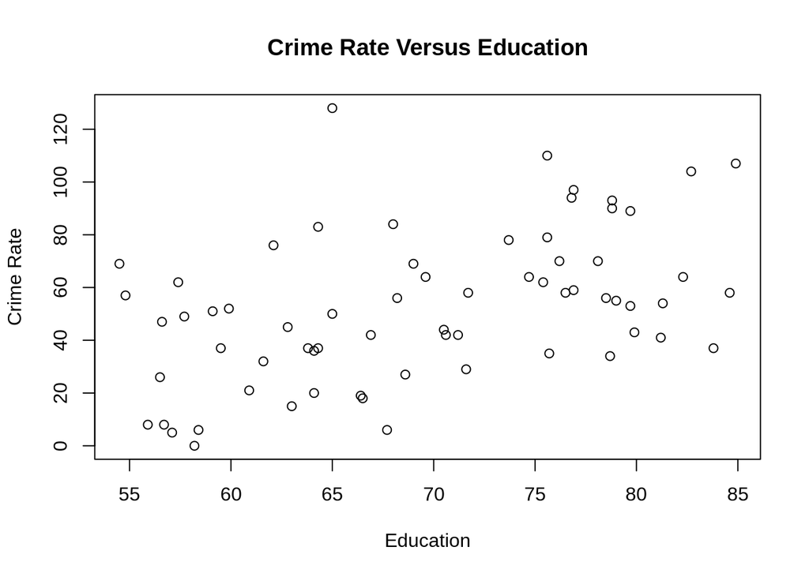

```r
plot(crime.rate ~ education, data = crime,
     xlab = "Education", ylab = "Crime Rate",
     main = "Crime Rate Versus Education")
```

## 1.2

The correlation between crime rate and education is:

```r
cor(crime$crime.rate, crime$education)
```

```
## [1] 0.4669119
```

Since this number is between one and zero, it indicates that there is some positive correlation between crime rate and education. The value is closer to zero than it is to one which indicates that the correlation is not very strong. Viewing a graph in which the means are plotted can help to illucidate which values contribute positively to this correlation and which contribute negatively.

```r
x <- crime$education
y <- crime$crime.rate

x.score <- x-mean(x)
y.score <- y-mean(y)
x.score*y.score
```

```
##  [1]  681.619670  174.637581   60.425640   10.788327  148.562954
##  [6]  304.092805  603.416685 -108.080330   22.597282 -133.534061
## [11]   24.698775   -8.125106 -248.781822   40.119670  330.483849
## [16]  118.083849 -169.499733  153.868924    3.864446  242.728626
## [21] -116.023613  103.200267  514.588327  -67.528091   69.642058
## [26]   -8.490777   -4.638539  351.943551  587.301760   39.237581
## [31]  160.970417   88.404745  591.606237  -11.551971   48.886834
## [36]  841.364446   49.522655  567.894297  342.962954  162.519670
## [41]    1.280864    6.095790 -339.396748  373.671909  -17.793763
## [46] -220.423613   14.576387  377.976387  107.774894  350.045043
## [51]   26.939073  151.518178  -47.065404 -158.784807   18.861461
## [56]   84.573402  -97.889285   12.371909   32.410715   79.934596
## [61]   87.636088 -174.371374   83.040566   56.722655  -49.390777
## [66]  102.849521  269.737581
```

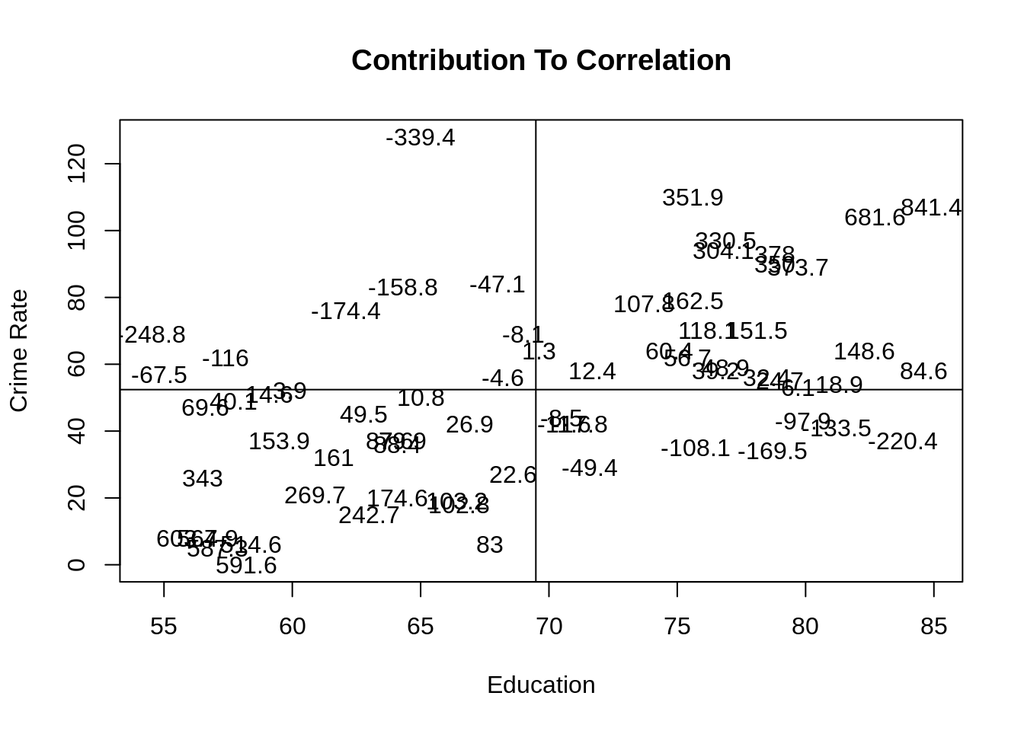

```r
plot(y~x, type="n", ylab = "Crime Rate", xlab = "Education", main = "Contribution To Correlation")
text(y~x, labels = round(x.score*y.score,1))
abline(h=mean(y), v=mean(x))
```

## 1.3

```r
lm.obj <- lm(crime.rate ~ education, data = crime)
lm.obj
```

```
##
## Call:
## lm(formula = crime.rate ~ education, data = crime)
##
## Coefficients:
## (Intercept)    education
##     -50.857        1.486
```

### a)

According to the linear fit the equation for the fitted linear regression of crime rate versus education is $\hat{y} = 1.486x - 50.857$. Looking at the overlapping graphs, This equation does seem to fit the data.

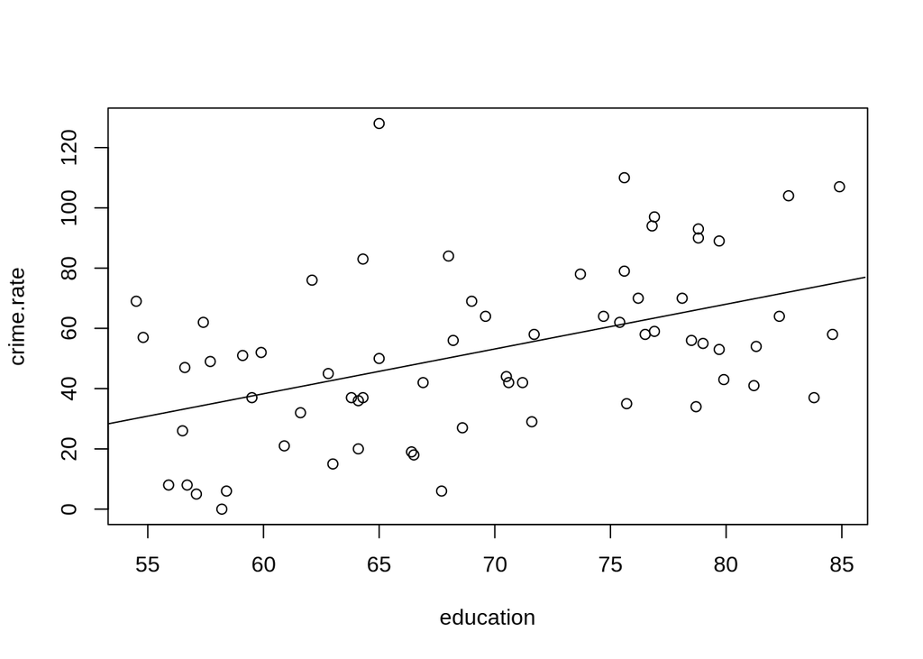

```r
plot(crime.rate~education, data = crime)
curve(1.486*x - 50.857, from  = 53, to = 86, add = T)
```

### b)

The intercept is -50.857 which would suggest a negative crime rate in population with no education. A negative crime rate would be nonsensical because the lowest level of crime that could exist would be none.

### c)

The slope indicated that a unit increase of education corresponds to a 1.486 unit increase in crime rate.

## 1.4

# Problem 2

```r
broadband <- read.csv(file.path(project.dir,dataset.dir,"Broadband_data.csv"))
str(broadband)
```

```
## 'data.frame':    32 obs. of  3 variables:
##  $ Country  : Factor w/ 32 levels "Argentina","Australia",..: 1 2 3 4 5 6 7 8 9 10 ...
##  $ GDP      : int  476 1532 483 2253 1821 270 8227 370 263 2613 ...
##  $ Broadband: int  4475415 5743000 3679196 18186954 11405500 2166805 175624800 3975161 2287249 23960000 ...
```

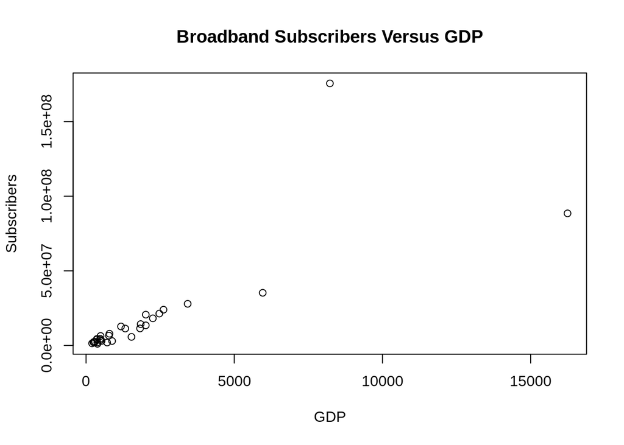

```r
plot(Broadband ~ GDP, data = broadband,
     ylab = "Subscribers", xlab = "GDP",
     main = "Broadband Subscribers Versus GDP")
```

## 3.26

### a)

```r
a <- 9.2 + 77*2000
b <- 9.2 + 77*3000

print(paste("The predicted value of a 2000 sq. ft. home is", a,
            "The predicted value of a 3000 sq. ft. home is", b))
```

```
## [1] "The predicted value of a 2000 sq. ft. home is 154009.2 The predicted value of a 3000 sq. ft. home is 231009.2"
```

### b)

The slop suggests that a one square foot increase in house size corresponds to a $77 increase in price.

### c)

The correlation between these variables is positive since an increase in square footage correlates to an increase in price.

### d)

```r
c <- 300000 - 231009.2
print(paste("The residual is", c))
```

```
## [1] "The residual is 68990.8"
```

Since the residual is positive, the prediction was an under estimate of the actual value. The regression predicts that the values of the home would be almost $70,000 less that it sold for.

## 3.70

### a)

1. b
2. a
3. c